# youtube-netflix-case

```python
import numpy as np
import pandas as pd
import matplotlib.pyplot as plt
import seaborn as sns

sns.set(style='whitegrid', font_scale=1.3)
%matplotlib inline
```

### Кейс 1

Задача заключается в работе с данными о трендах на YouTube. В этом нам поможет библиотека `seaborn`.

[figure not shown]

```python
from datetime import datetime as dt
parse = lambda x: dt.strptime(x,'%y.%d.%m')

videos = pd.read_csv("RUvideos_short.csv",
                       parse_dates=['trending_date'],
                       date_parser=parse,
                       dayfirst=True)
videos.head()
```

|  | video_id | trending_date | title | channel_title | category_id | publish_time | tags | views | likes | dislikes | comment_count | thumbnail_link | comments_disabled | ratings_disabled | video_error_or_removed | description |
| --- | --- | --- | --- | --- | --- | --- | --- | --- | --- | --- | --- | --- | --- | --- | --- | --- |
| 0 | gDuslQ9avLc | 2017-11-14 | Захар и Полина учатся экономить | Т—Ж БОГАЧ | 22 | 2017-11-13T09:09:31.000Z | захар и полина\|"учимся экономить"\|"копить день... | 62408 | 334 | 190 | 50 | https://i.ytimg.com/vi/gDuslQ9avLc/default.jpg | False | False | False | Знакомьтесь, это Захар и Полина. Вместе с ними... |
| 1 | AOCJIFEA_jE | 2017-11-14 | Биржа Мемов #29. Большой выпуск | Druzhko Show | 22 | 2017-11-13T17:32:11.000Z | биржа мемов\|"лев шагинян"\|"мемы"\|"пикчи"\|"друж... | 330043 | 43841 | 2244 | 2977 | https://i.ytimg.com/vi/AOCJIFEA_jE/default.jpg | False | False | False | В 29 выпуске Дружко Шоу Сергей сказал, что Бир... |
| 2 | VAWNQDgwwOM | 2017-11-14 | ХАЙП КЭМП - СВОЙ СРЕДИ ЧУЖИХ | Юлик | 24 | 2017-11-13T16:11:31.000Z | юмор\|"комедия"\|"влог"\|"блог"\|"смешно"\|"смешное... | 424596 | 49854 | 714 | 2944 | https://i.ytimg.com/vi/VAWNQDgwwOM/default.jpg | False | False | False | http://kapitany.ru/!Yulik.cap - Факультет #Кап... |
| 3 | gknkFwKQfHg | 2017-11-14 | Сочная кесадилья с курицей | Hochland | 22 | 2017-11-13T06:51:10.000Z | хохланд\|"сыр"\|"рецепты"\|"как приготовить"\|"вку... | 112851 | 3566 | 122 | 80 | https://i.ytimg.com/vi/gknkFwKQfHg/default.jpg | False | False | False | *** как готовить ресторанные блюда дома |
| 4 | 3sYvZcwzZr8 | 2017-11-14 | КЛИПЫ РОДИТЕЛЕЙ НА ШКОЛЬНЫЙ ВЫПУСКНОЙ | Совергон | 24 | 2017-11-13T16:52:36.000Z | Совергон\|"Sovergon"\|"клипы"\|"родители"\|"школа"... | 243469 | 36216 | 631 | 1692 | https://i.ytimg.com/vi/3sYvZcwzZr8/default.jpg | False | False | False | ❏ КОНКУРС КАПИТАНЫ: http://kapitany.ru/!Soverg... |

В таблице много лишних данных. Оставим следующие столбцы:

- `trending_date` -- дата в формате год-день-месяц;
- `category_id` -- категория видео, названия приведены в файле `RU_category_id.json`;
- `views` -- количество просмотров видео;
- `likes` -- количество лайков;
- `dislikes` -- количество дислайков;
- `comment_count` -- количество комментариев.

Из даты оставим только день. Для этого можно пройтись циклом по всем датам и взять поле `day` у даты. Напечатайте начало таблицы.

```python
youtube = videos[
            ['trending_date',
             'category_id',
             'views',
             'likes',
             'dislikes',
             'comment_count']]

youtube.trending_date = youtube['trending_date'].dt.day
youtube.head()
```

|  | trending_date | category_id | views | likes | dislikes | comment_count |
| --- | --- | --- | --- | --- | --- | --- |
| 0 | 14 | 22 | 62408 | 334 | 190 | 50 |
| 1 | 14 | 22 | 330043 | 43841 | 2244 | 2977 |
| 2 | 14 | 24 | 424596 | 49854 | 714 | 2944 |
| 3 | 14 | 22 | 112851 | 3566 | 122 | 80 |
| 4 | 14 | 24 | 243469 | 36216 | 631 | 1692 |

**2. Некоторая визуализация**

Построим ящики с усами на каждый день по количеству просмотров.

```python
(videos['views'].max()+videos['views'].mean())/10
```

```
869921.11625
```

```
[(0.0, 869921.0)]
```

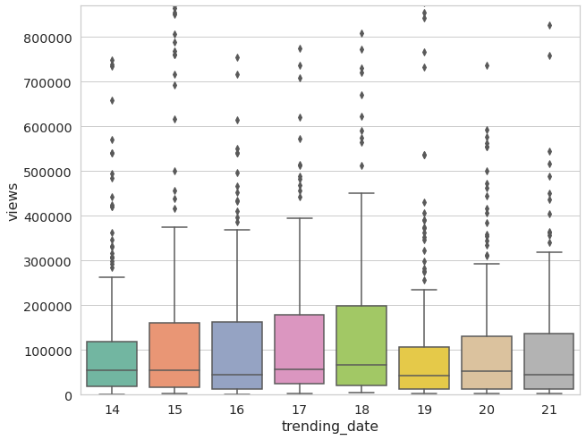

```python
plt.figure(figsize=(10, 8))
sns.boxplot(
    data=youtube,
    y='views',
    x='trending_date',
    palette='Set2').set(ylim=(0, 869921))
```

Построим jointplot по всем данным для количества просмотров по горизонтальной оси и количества лайков по вертикальной.

```python
videos.describe().transpose()
```

|  | count | mean | std | min | 25% | 50% | 75% | max |
| --- | --- | --- | --- | --- | --- | --- | --- | --- |
| category_id | 1600.0 | 20.024375 | 8.475180 | 1.0 | 20.00 | 22.0 | 25.00 | 43.0 |
| views | 1600.0 | 165385.162500 | 442078.329158 | 1058.0 | 15342.00 | 50218.5 | 148866.00 | 8533826.0 |
| likes | 1600.0 | 8468.100625 | 29560.407950 | 0.0 | 207.50 | 1186.5 | 6020.25 | 789772.0 |
| dislikes | 1600.0 | 995.541250 | 4727.892085 | 0.0 | 19.75 | 89.0 | 404.25 | 86001.0 |
| comment_count | 1600.0 | 1153.681875 | 4979.302130 | 0.0 | 40.00 | 188.5 | 756.50 | 100581.0 |

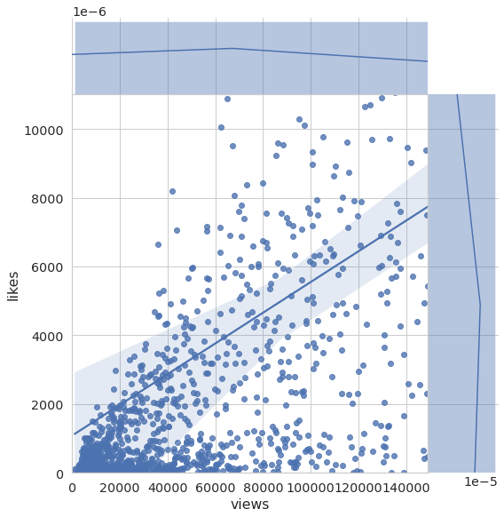

```python
sns.jointplot(
    x='views',
    y='likes',
    xlim=(0, 148866),
    ylim=(0, 11020),
    kind='reg',
    data=youtube,
    height=8,
    space=0)
```

### Кейс 2

Netflix за последние 5-10 лет обзавелись большим количеством зрителей. С увеличением числа зрителей увеличилось и разнообразие шоу. Соответственно, перед аналитиками из киноиндустрии встала задача исследования данных с рейтингами различных сериалов.  
В данном задании мне предстоит провести визуальный анализ датасета **1000 Netflix Shows** (по состоянию на 11.06.2017) и сделать выводы.

[figure not shown]

Описание признаков:

- `title` - название шоу.
- `rating` - рейтинг шоу. Например: G, PG, TV-14, TV-MA
- `ratingLevel` - описание рейтинговой группы и особенностей шоу.
- `release year` - год выпуска шоу.
- `user rating score` - оценка пользователей.

```python
data = pd.read_csv('netflix_data.csv', encoding='cp437')
del data['ratingDescription'], data['user rating size']
```

Удалим из данных дупликаты. Сколько объектов удалено?

```python
size_with_duples = len(data)
data.drop_duplicates(inplace=True)
size_with_duples - len(data)
```

```
500
```

Сколько объектов осталось?

```python
len(data)
```

```
500
```

Сколько рейтинговых групп представлено в данных?

```python
len(data.rating.drop_duplicates())
```

```
13
```

Какие оценки пользователи ставят чаще? Постройте гистограмму оценок.

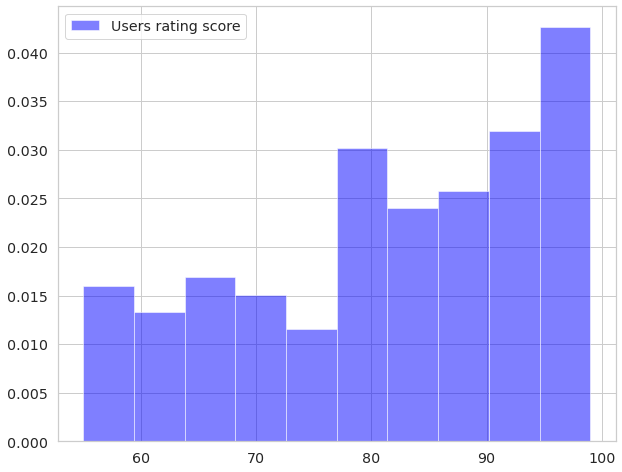

```python
plt.figure(figsize=(10,8))
plt.hist(
    data['user rating score'],
    bins=10,
    density=True,
    alpha=0.5,
    color='blue',
    label='Users rating score')

plt.legend()
plt.show()
```

```python
data['user rating score'].mean()
```

```
81.3984375
```

Выведим основную информацию об оценках пользователей: среднее, стандартное отклонение, минимум, максимум, медиана.

```python
data['user rating score'].describe()
```

```
count    256.000000
mean      81.398438
std       12.730904
min       55.000000
25%       71.000000
50%       83.500000
75%       93.000000
max       99.000000
Name: user rating score, dtype: float64
```

**Еомментарий:** Медиана и среднее отличаются. Медиана и среднее могут значительно отличаться, т.к. медиана более устайяива к выбросам.

В какие годы были запущены шоу, представленные в датасете?

```python
sorted(data['release year'].drop_duplicates())
```

```
[1940,
 1976,
 1978,
 1982,
 1986,
 1987,
 1989,
 1990,
 1991,
 1992,
 1993,
 1994,
 1995,
 1996,
 1997,
 1998,
 1999,
 2000,
 2001,
 2002,
 2003,
 2004,
 2005,
 2006,
 2007,
 2008,
 2009,
 2010,
 2011,
 2012,
 2013,
 2014,
 2015,
 2016,
 2017]
```

Построим график, показывающий распределение количества запущенных шоу в зависимости от года. Наблюдается ли рост? Есть ли выбросы?

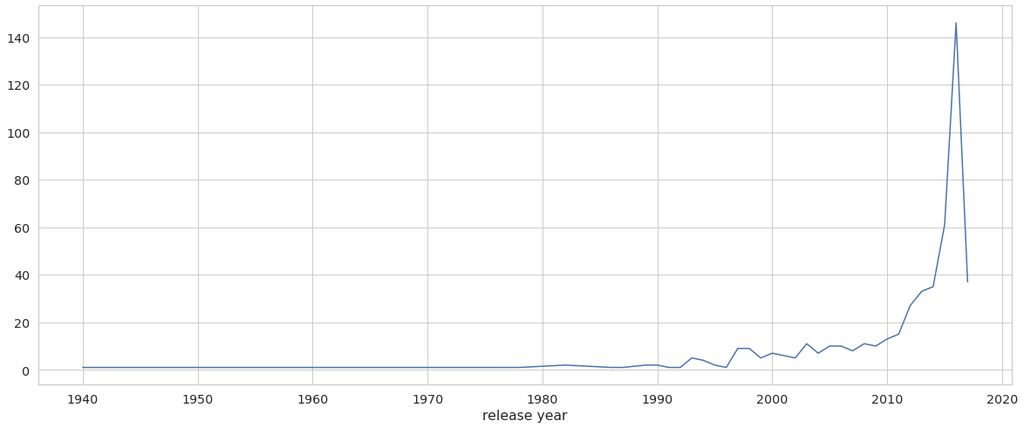

```python
plt.figure(figsize=(20, 8))
data.groupby('release year').count().title.plot()
```

**Вывод:** количество запущенных шоу начало возрастать в середине 1990-го десятилетия, отмечаю взрывной рос в середине 2010-го десятилетия. Скорее всего рост наблюдается благодаря переходу на стриминговый сервис.

Сравним среднюю оценку пользователей в 2016 со средней оценкой в 2017. Можно ли сделать вывод, что 2017 год успешнее для Netflix? ("Успешнее" значит, что пользователи в среднем ставили более высокие оценки) Ответить на этот вопрос мне поможет график, который я построил выше.

```python
print('2016: ', data.groupby('release year').mean().loc[2016])
print('2017: ',data.groupby('release year').mean().loc[2017])
```

```
2016:  user rating score    84.313953
Name: 2016, dtype: float64
2017:  user rating score    88.125
Name: 2017, dtype: float64
```

```python
data.groupby('release year').count().title.tail()
```

```
release year
2013     33
2014     35
2015     61
2016    146
2017     37
Name: title, dtype: int64
```

**Вывод:** 2017 выдался более успешным для компании. Однако мы можем наблюдать резкое адение количества выпускаемых шоу..

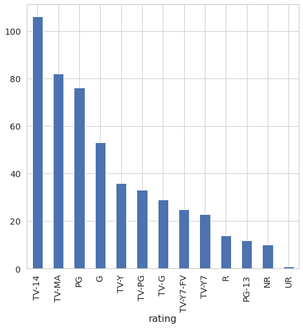

```python
data.groupby('rating').size().sort_values(
    ascending=False).plot(
    kind='bar',
    figsize=(8, 8),
    label='rating')
```

Составим топ-13 самых высоко оцененных шоу. Выберем из данного топа шоу, которое наиболее нравится. Обозначим это шоу N. Ответим на следующие вопросы:

- Какое шоу является худшим по оценкам в рейтинговой группе, к которой принадлежит N?
- Сколько шоу было выпущено в одном году с N?
- Насколько бы изменилась средняя оценка шоу, выпущенных в одном году с N, если бы Netflix не запустили шоу N?

```python
data.sort_values('user rating score', ascending=False).head(13)
```

|  | title | rating | ratingLevel | release year | user rating score |
| --- | --- | --- | --- | --- | --- |
| 41 | 13 Reasons Why | TV-MA | For mature audiences. May not be suitable for... | 2017 | 99.0 |
| 350 | Lost | TV-14 | Parents strongly cautioned. May be unsuitable ... | 2010 | 98.0 |
| 10 | Once Upon a Time | TV-PG | Parental guidance suggested. May not be suitab... | 2016 | 98.0 |
| 64 | Friends | TV-14 | Parents strongly cautioned. May be unsuitable ... | 2003 | 98.0 |
| 72 | Orange Is the New Black | TV-MA | For mature audiences. May not be suitable for... | 2016 | 98.0 |
| 27 | The Flash | TV-PG | Parental guidance suggested. May not be suitab... | 2016 | 98.0 |
| 25 | Marvel's Iron Fist | TV-MA | NaN | 2017 | 98.0 |
| 88 | Finding Dory | PG | mild thematic elements | 2016 | 98.0 |
| 62 | Family Guy | TV-MA | For mature audiences. May not be suitable for... | 2015 | 98.0 |
| 63 | Criminal Minds | TV-14 | Parents strongly cautioned. May be unsuitable ... | 2016 | 98.0 |
| 3 | Prison Break | TV-14 | Parents strongly cautioned. May be unsuitable ... | 2008 | 98.0 |
| 2 | Grey's Anatomy | TV-14 | Parents strongly cautioned. May be unsuitable ... | 2016 | 98.0 |
| 8 | The Walking Dead | TV-MA | For mature audiences. May not be suitable for... | 2015 | 98.0 |

Взял "Family Guy", категория - "TV-MA", год выпуска - 2015, средняя оценка - 98.0

```python
print('Худшее по оценкам шоу, категории TV-MA - ',
      data[data.rating == 'TV-MA'].sort_values(
          by='user rating score').dropna().head(1).title)
```

```
Худшее по оценкам шоу, категории TV-MA -  380    Bitten
Name: title, dtype: object
```

```python
print("Шоу выпущенных в одном году с Family Guy -",
      len(data[data['release year'] == 2015]))
```

```
Шоу выпущенных в одном году с Family Guy - 61
```

```python
ans = data[data['release year'] == 2015].set_index('title').drop(
    ['Family Guy']).mean()['user rating score']
print("Средний рейтинг шоу 2015 года, без Family Guy -", int(ans))
```

```
Средний рейтинг шоу 2015 года, без Family Guy - 82
```

Ответим на следующие вопросы при помощи `boxplot`:

- Какую рейтинговую группу зрители оценивали выше всего в последние пять лет?
- Как менялись оценки пользователей с течением времени? Построим `boxplot` для каждого десятилетия.

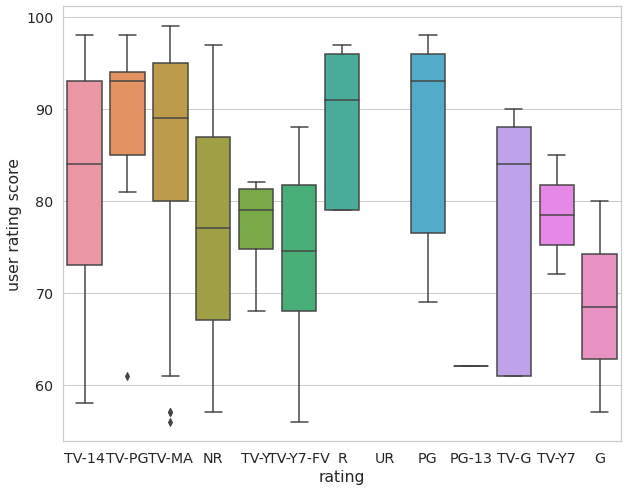

```python
plt.figure(figsize=(10,8))
sns.boxplot(
    x='rating',
    y='user rating score',
    data=data[data['release year'] > 2012]);
```

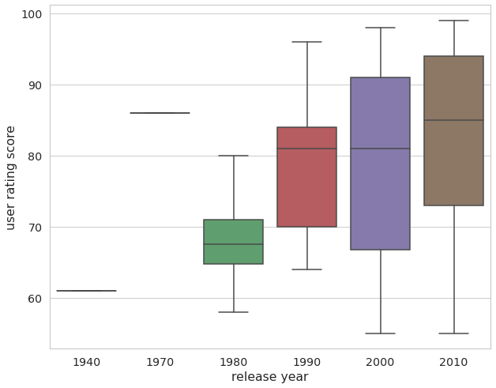

```python
tmp = data
tmp['release year'] = data['release year'] - data['release year'] % 10
plt.figure(figsize=(10,8))
sns.boxplot(
    x='release year',
    y='user rating score',
    data=tmp)
```